# Objective : To Predict whether a user will click on an Ad

1. Introduction

1.1 Defining the Question

The task is to perform EDA on the dataset to draw insights on whether a user will click an Ad.

1.2 The Context

Research Question

A Kenyan entrepreneur has created an online cryptography course and would want to advertise it on her blog. She currently targets audiences originating from various countries. In the past, she ran ads to advertise a related course on the same blog and collected data in the process. She would now like to employ your services as a Data Science Consultant to help her identify which individuals are most likely to click on her ads.

1.1.3 Metrics for Success Deriving Insight based on Analysis

1.1.4 Experimental Design Taken Installing packages and loading libraries needed Loading the data Data Cleaning EDA Conclusion

1.1.5 Appropriateness of the Data Dataset link: http://bit.ly/IPAdvertisingData

The columns in the dataset include:

Daily Time Spent on Site Age Area Income Daily Internet Usage Ad Topic Line City Male - 1 for male, O for female Country Time Stamp Clicked on Ad

```r
#install.packages()
```

```r
#local({r <- getOption("repos"); r["CRAN"] <- "https://cran.r-project.org/"; options(repos = r)})
```

local({r <- getOption(“repos”); r[“CRAN”] <- “https://cran.r-project.org/”; options(repos = r)})

```r
local({r <- getOption("repos"); r["CRAN"] <- "https://cran.r-project.org/"; options(repos = r)})
```

```r
getOption("repos")
```

```
##                          CRAN
## "https://cran.r-project.org/"
```

```r
options(repos = c(CRAN = "https://cran.rstudio.org"))
```

```r
library(xfun)
```

# Installing necessary packages

```r
install.packages('xfun')
install.packages("tidyverse")
library("tidyverse")
library("data.table")
data <- fread("http://bit.ly/IPAdvertisingData")
```

```r
# Checking the first 5 rows

head(data)
```

```
##    Daily Time Spent on Site Age Area Income Daily Internet Usage
## 1:                    68.95  35    61833.90               256.09
## 2:                    80.23  31    68441.85               193.77
## 3:                    69.47  26    59785.94               236.50
## 4:                    74.15  29    54806.18               245.89
## 5:                    68.37  35    73889.99               225.58
## 6:                    59.99  23    59761.56               226.74
##                            Ad Topic Line           City Male    Country
## 1:    Cloned 5thgeneration orchestration    Wrightburgh    0    Tunisia
## 2:    Monitored national standardization      West Jodi    1      Nauru
## 3:      Organic bottom-line service-desk       Davidton    0 San Marino
## 4: Triple-buffered reciprocal time-frame West Terrifurt    1      Italy
## 5:         Robust logistical utilization   South Manuel    0    Iceland
## 6:       Sharable client-driven software      Jamieberg    1     Norway
##              Timestamp Clicked on Ad
## 1: 2016-03-27 00:53:11             0
## 2: 2016-04-04 01:39:02             0
## 3: 2016-03-13 20:35:42             0
## 4: 2016-01-10 02:31:19             0
## 5: 2016-06-03 03:36:18             0
## 6: 2016-05-19 14:30:17             0
```

```r
# Checking the last 5 rows

tail(data)
```

```
##    Daily Time Spent on Site Age Area Income Daily Internet Usage
## 1:                    43.70  28    63126.96               173.01
## 2:                    72.97  30    71384.57               208.58
## 3:                    51.30  45    67782.17               134.42
## 4:                    51.63  51    42415.72               120.37
## 5:                    55.55  19    41920.79               187.95
## 6:                    45.01  26    29875.80               178.35
##                           Ad Topic Line          City Male
## 1:        Front-line bifurcated ability  Nicholasland    0
## 2:        Fundamental modular algorithm     Duffystad    1
## 3:      Grass-roots cohesive monitoring   New Darlene    1
## 4:         Expanded intangible solution South Jessica    1
## 5: Proactive bandwidth-monitored policy   West Steven    0
## 6:      Virtual 5thgeneration emulation   Ronniemouth    0
##                   Country           Timestamp Clicked on Ad
## 1:                Mayotte 2016-04-04 03:57:48             1
## 2:                Lebanon 2016-02-11 21:49:00             1
## 3: Bosnia and Herzegovina 2016-04-22 02:07:01             1
## 4:               Mongolia 2016-02-01 17:24:57             1
## 5:              Guatemala 2016-03-24 02:35:54             0
## 6:                 Brazil 2016-06-03 21:43:21             1
```

```r
# Checking the number of rows and columns in the dataset

dim(data)
```

```
## [1] 1000   10
```

```r
# This daaset has 1000 rows and 10 columns
```

```r
# checking the types of attributes/data types

sapply(data, class)
```

```
## Daily Time Spent on Site                      Age              Area Income
##                "numeric"                "integer"                "numeric"
##     Daily Internet Usage            Ad Topic Line                     City
##                "numeric"              "character"              "character"
##                     Male                  Country                Timestamp
##                "integer"              "character"              "character"
##            Clicked on Ad
##                "integer"
```

```r
# Statistical Summary

summary(data)
```

```
##  Daily Time Spent on Site      Age         Area Income    Daily Internet Usage
##  Min.   :32.60            Min.   :19.00   Min.   :13996   Min.   :104.8
##  1st Qu.:51.36            1st Qu.:29.00   1st Qu.:47032   1st Qu.:138.8
##  Median :68.22            Median :35.00   Median :57012   Median :183.1
##  Mean   :65.00            Mean   :36.01   Mean   :55000   Mean   :180.0
##  3rd Qu.:78.55            3rd Qu.:42.00   3rd Qu.:65471   3rd Qu.:218.8
##  Max.   :91.43            Max.   :61.00   Max.   :79485   Max.   :270.0
##  Ad Topic Line          City                Male         Country
##  Length:1000        Length:1000        Min.   :0.000   Length:1000
##  Class :character   Class :character   1st Qu.:0.000   Class :character
##  Mode  :character   Mode  :character   Median :0.000   Mode  :character
##                                        Mean   :0.481
##                                        3rd Qu.:1.000
##                                        Max.   :1.000
##   Timestamp         Clicked on Ad
##  Length:1000        Min.   :0.0
##  Class :character   1st Qu.:0.0
##  Mode  :character   Median :0.5
##                     Mean   :0.5
##                     3rd Qu.:1.0
##                     Max.   :1.0
```

Data Cleaning

```r
# Checking for missing values in the dataset

colSums(is.na(data))
```

```
## Daily Time Spent on Site                      Age              Area Income
##                        0                        0                        0
##     Daily Internet Usage            Ad Topic Line                     City
##                        0                        0                        0
##                     Male                  Country                Timestamp
##                        0                        0                        0
##            Clicked on Ad
##                        0
```

```r
# There are o missing values in this dataset
```

Making the Column Names neat by removing the spaces

```r
# Checking the column names

names(data)
```

```
##  [1] "Daily Time Spent on Site" "Age"
##  [3] "Area Income"              "Daily Internet Usage"
##  [5] "Ad Topic Line"            "City"
##  [7] "Male"                     "Country"
##  [9] "Timestamp"                "Clicked on Ad"
```

```r
# Replacing spaces in the columns names with a .
names(data) <- gsub(" ", ".", names(data))
```

```r
# Checking to confirm that the changes have been effected

names(data)
```

```
##  [1] "Daily.Time.Spent.on.Site" "Age"
##  [3] "Area.Income"              "Daily.Internet.Usage"
##  [5] "Ad.Topic.Line"            "City"
##  [7] "Male"                     "Country"
##  [9] "Timestamp"                "Clicked.on.Ad"
```

Univariate Analysis Mean Median Mode Maximum Minimum Range Quantile Variance Standard Deviation Boxplot

```r
sapply(data, class)
```

```
## Daily.Time.Spent.on.Site                      Age              Area.Income
##                "numeric"                "integer"                "numeric"
##     Daily.Internet.Usage            Ad.Topic.Line                     City
##                "numeric"              "character"              "character"
##                     Male                  Country                Timestamp
##                "integer"              "character"              "character"
##            Clicked.on.Ad
##                "integer"
```

The Mean age is 36

```r
# Checking the mean age

data.Age.mean <- mean(data$Age)

data.Age.mean
```

```
## [1] 36.009
```

The median age is 35

```r
data.Age.median <- median(data$Age)

data.Age.median
```

```
## [1] 35
```

# Creating a function to check the mode

```r
getmode <- function(v) {
   uniqv <- unique(v)
   uniqv[which.max(tabulate(match(v, uniqv)))]
}
```

```r
data.Age.mode <- getmode(data$Age)

data.Age.mode
```

```
## [1] 31
```

The Modal age is 31

```r
# The minimum and maximum ages
data.Age.min <- min(data$Age)

data.Age.min
```

```
## [1] 19
```

```r
data.Age.max <- max(data$Age)

data.Age.max
```

```
## [1] 61
```

The minimum and maximum ages are 19 and 61 respectively

The age range is 19 to 61

```r
data.Age.range <- range(data$Age)

data.Age.max
```

```
## [1] 61
```

This is the interquartile range

```r
data.Age.quantile <- quantile(data$Age)

data.Age.quantile
```

```
##   0%  25%  50%  75% 100%
##   19   29   35   42   61
```

This is the Variance

```r
data.Age.variance <- var(data$Age)

data.Age.variance
```

```
## [1] 77.18611
```

Box plot for age

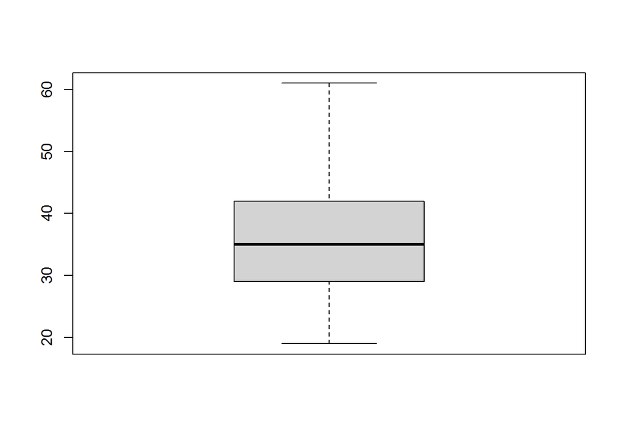

```r
boxplot(data$Age)
```

```r
data.Daily.Time.Spent.on.Site.mean <- mean(data$Daily.Time.Spent.on.Site)

data.Daily.Time.Spent.on.Site.mean
```

```
## [1] 65.0002
```

The mean time spent on the site daily is 65 minutes

```r
data.Daily.Time.Spent.on.Site.median <- median(data$Daily.Time.Spent.on.Site)

data.Daily.Time.Spent.on.Site.median
```

```
## [1] 68.215
```

The median amount of time spent daily on the site is 68 minutes

```r
data.Daily.Time.Spent.on.Site.min <- min(data$Daily.Time.Spent.on.Site)

data.Daily.Time.Spent.on.Site.min
```

```
## [1] 32.6
```

```r
data.Daily.Time.Spent.on.Site.max <- max(data$Daily.Time.Spent.on.Site)

data.Daily.Time.Spent.on.Site.max
```

```
## [1] 91.43
```

The minimum and maximum amount of time spent daily on the website is 32 and 91 minutes respectively

```r
data.Daily.Time.Spent.on.Site.variance <- var(data$Daily.Time.Spent.on.Site)

data.Daily.Time.Spent.on.Site.variance
```

```
## [1] 251.3371
```

UNIVARIATE ANALYSIS ON Area Income

```r
data.Area.Income.mean <- mean(data$Area.Income)

data.Area.Income.mean
```

```
## [1] 55000
```

The average income is $55,000

```r
data.Area.Income.median <- median(data$Area.Income)

data.Area.Income.median
```

```
## [1] 57012.3
```

```r
data.Area.Income.min <- min(data$Area.Income)

data.Area.Income.min
```

```
## [1] 13996.5
```

```r
data.Area.Income.max <- max(data$Area.Income)

data.Area.Income.max
```

```
## [1] 79484.8
```

- The lowest income is $13,996 and the highest amount is $79,484.8 per annum

```r
data.Area.Income.variance <- var(data$Area.Income)

data.Area.Income.variance
```

```
## [1] 179952406
```

Boxplot for Income

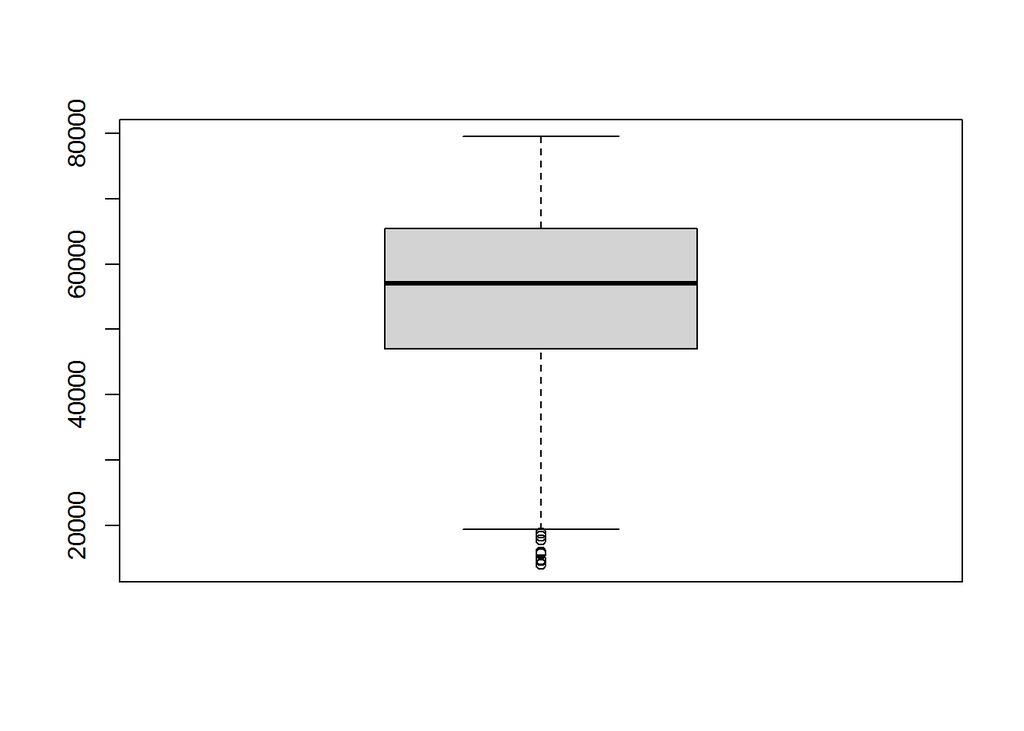

```r
boxplot(data$Area.Income)
```

- There are a few Outliers on the lower income scale, but we won’t drop them because they are true representatives of earning capacity.

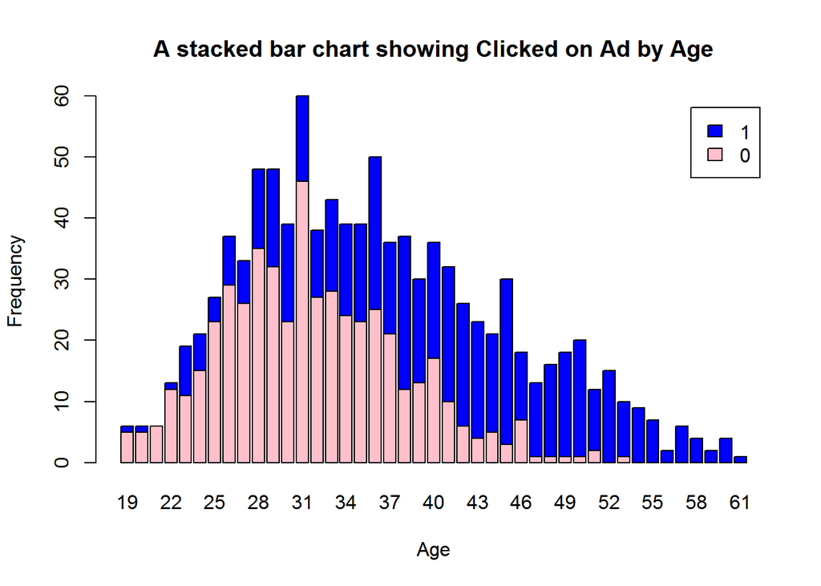

```r
# Stacked bar chart


# Giving a title to the chart
# Labeling the x and y axis
# Setting the color options
# Creating a legend for easier reference

counts <- table(data$Clicked.on.Ad, data$Age)
barplot(counts,
  main="A stacked bar chart showing Clicked on Ad by Age",
  xlab="Age",
  ylab = "Frequency",
  col=c("pink","blue"),
  legend = rownames(counts))
```

- 1 shows that the participant clicked on an Ad.

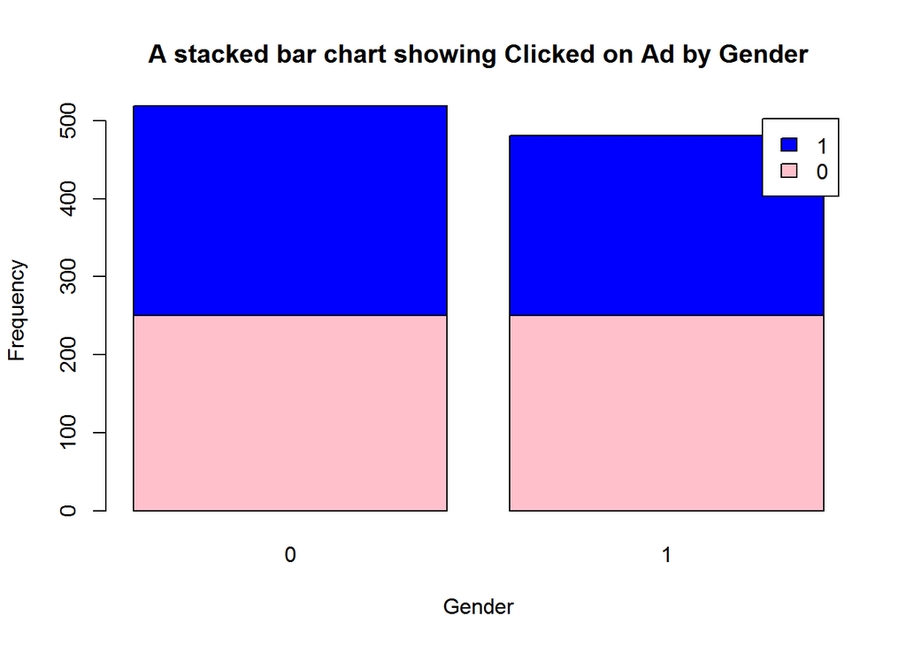

```r
counts <- table(data$Clicked.on.Ad, data$Male)
barplot(counts,
  main="A stacked bar chart showing Clicked on Ad by Gender",
  xlab="Gender",
  ylab = "Frequency",
  col=c("pink","blue"),
  legend = rownames(counts))
```

- From the fgure above, there are more female participants, and that translates to more females clicking in the ads.

```r
install.packages("CGPfunctions")
```

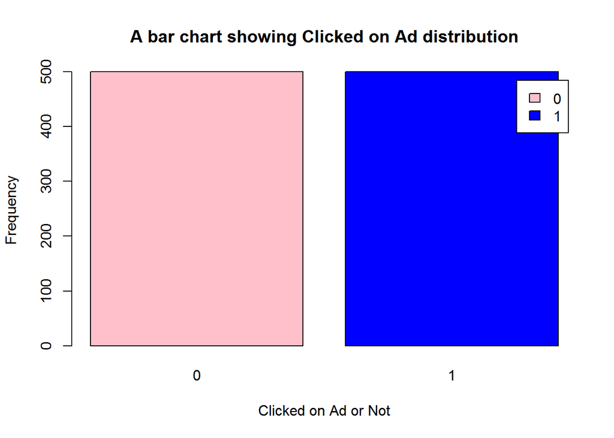

```r
# Bar chart of the target variable

counts <- table(data$Clicked.on.Ad)
barplot(counts,
  main="A bar chart showing Clicked on Ad distribution",
  xlab="Clicked on Ad or Not",
  ylab = "Frequency",
  col=c("pink","blue"),
  legend = rownames(counts))
```

- 50% of the users clicked on ad and 50% did not click on the ads

Multivariate Analysis

```r
library("ggplot2")
```

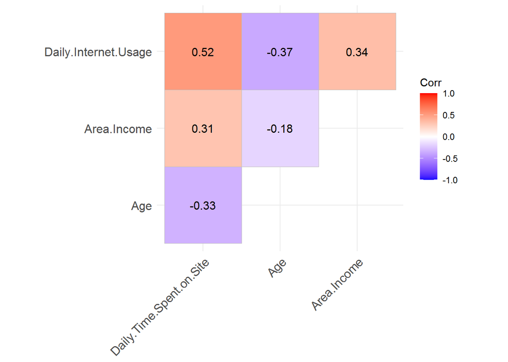

```r
install.packages("ggcorrplot")
library("ggcorrplot")
# Heat map
# Checking the relationship between the variables using numeric variables


numeric_tbl <- data %>%
  select_if(is.numeric) %>%
  select(Daily.Time.Spent.on.Site, Age, Area.Income,Daily.Internet.Usage)

# Calculating the correlations
corr <- cor(numeric_tbl, use = "complete.obs")

ggcorrplot(round(corr, 2),
           type = "upper", lab = TRUE)
```

- There is a positive high correlation between the daily time spent on the internet and Time spent on the site

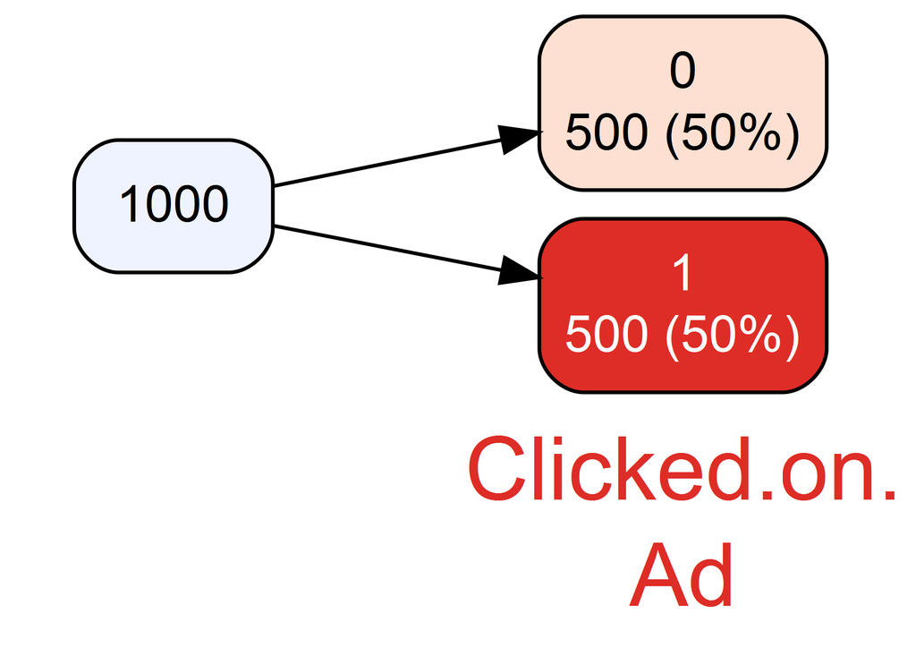

```r
install.packages("vtree")
library(vtree)
vtree(data, "Clicked.on.Ad")
```

- Based on the image below, 50% of the users clicked on the ad and 50% of them didn’t

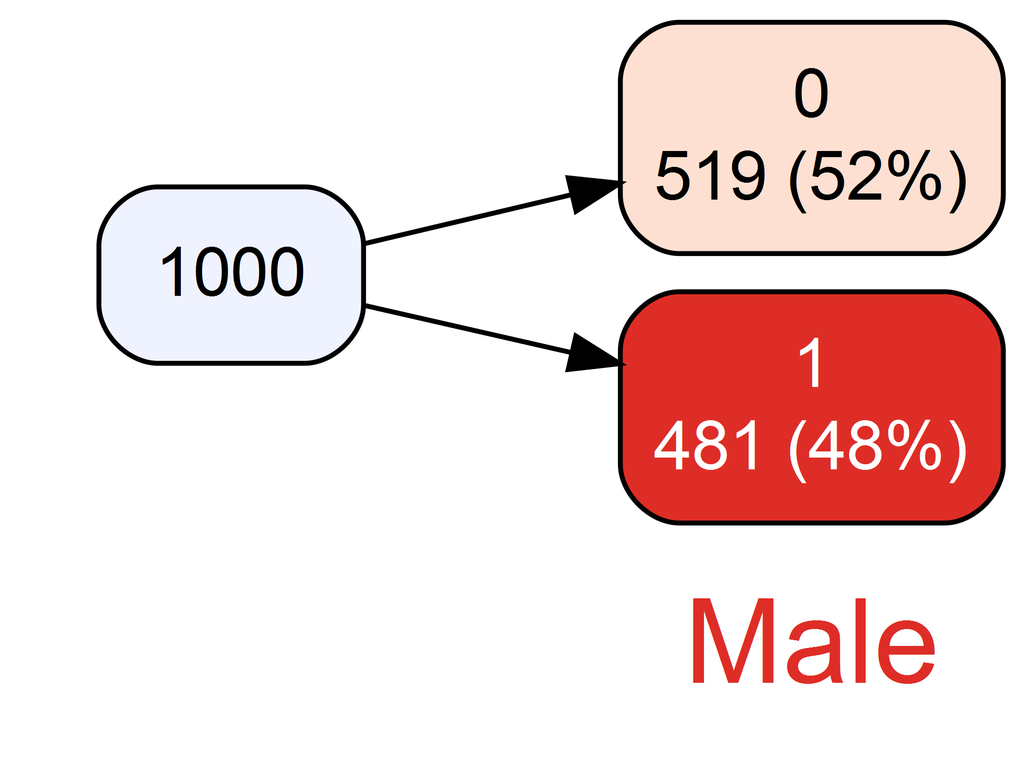

```r
vtree(data, "Male")
```

- There are more Female Participants at 52%

```r
library("tidyr")
library("dplyr")
library("purrr")
```

```r
install.packages("ggsci")
library("ggsci") # to add aaas color palette
#vtree(data, c("Male", "Clicked.on.Ad"),
  # fillcolor = c( Male = "#e7d4e", Clicked.on.Ad = "#99d8f"),
   #horiz = FALSE)
```